# Citi Bike Ridership Pattern Impacted by Covid-19 Pandemic

## by GimPei Ng

## Investigation Overview

In this investigation, I wanted to look at the Citi Bike ridership trend varies before and during Covid-19 Pandemic, that is trend in 2019 (pre-Covid-19) and 2020. The main focus was on key influence of the change in user type: Subscriber (Annual Member) and Customer (1-day or 3-day user). Variables with trends varies based on the user type were investigated. They are trip duration, frequency of ridershp by day of week and time of day, and the popular route (defined by start station and end station).

## Dataset Overview

The data consisted of 708780 Citi Bike rides from 2019 to Oct 2020. They are information about individual rides made, including variables like the trip duration, start station name, end station name, user type, gender, birth year, bike id and others. About 0.9% of data were removed from the analysis due to abnormal value, for example user age of more than or equal to 80 years old.

## Distribution of Ridership

There are two user types in Citi Bike data system, **Subscriber** (Annual Member) and **Customer** (1-day pass or 3-day pass user). Total number of users plummeted in year 2020 but there a surge in Customer user in 2020.

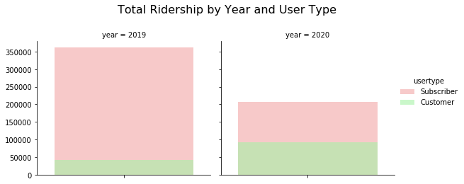

```python
# Total Ridership by year
g = sns.FacetGrid(data = df, col = 'year', hue = 'usertype',
                 height = 4, palette=colors_usertype)
g.map(sns.countplot, 'year', alpha = 0.6)

g.set(xticklabels = [])  # remove xticks
g.set_xlabels("")
g.add_legend();

# add main title
plt.subplots_adjust(top = 0.8)
g.fig.suptitle("Total Ridership by Year and User Type", fontsize = 16);
```

## Distribution of Ridership by month

In the first 2 months of 2020 (Jan-Feb), ridership increases compared to same period last year. However, trend changed from March 2020 onwards. Number of Customer user surge, particularly in the month of **May - Aug**.

As Covid-19 has huge impact on the trend observed in year 2020, below is the key dates of government response to the Covid-19 in NY (state):

- March 22 : PAUSE order in effect at 8pm
- Apr 6. : statewide PAUSE order extended through April 29
- Apr 16. : statewide PAUSE order extended through May 15
- June 8. : Phase 1 reopening
- June 22. : Phase 2 reopen
- July 6. : Phase 3 reopen, exclude indoor dining
- July 20. : Phase 4 reopen

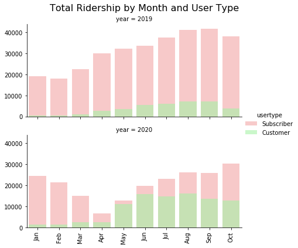

```python
# Now, break down to monthly ridership, by each year
month_list = ['Jan','Feb', 'Mar', 'Apr', 'May', 'Jun',
             'Jul', 'Aug', 'Sep', 'Oct', 'Nov', 'Dec']

g = sns.FacetGrid(data = df, row = 'year', hue = 'usertype',
                 height = 3, aspect = 2, palette=colors_usertype)
g.map(sns.countplot, 'month', alpha = 0.6)
g.add_legend()

# set xticks
for ax in g.axes.ravel():
    ax.set_xticklabels(month_list, rotation = 90)
plt.subplots_adjust(hspace = 0.2)
g.set_xlabels("")

# add main title
plt.subplots_adjust(top = 0.9)
g.fig.suptitle("Total Ridership by Month and User Type", fontsize = 16);
```

## Distribution of Trip Duration

Trip duration take on a very large range of values, but 75 percentile of the trip duration is < 14.3 min. However, there are outliers with extreme long trip duration, max up to approximately 37 days, which is not realistics. In addition, users need to pay extra if they exceed the time limit (30 mins for Customer, 45 mins for Subscriber). With this in mind, user typically won't exceed the total single riding time by 2 hours. Thus, the dataset remove the entries with trip duration exceeding 2 hours.  
Bar plot showed the overall trip duration increases in 2020, regardless of user type.

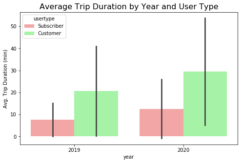

```python
# Average trip duration by year and user type
plt.figure(figsize = [8,5])

sns.barplot(data = df, x = 'year', y = 'tripduration', hue='usertype',
           palette=colors_usertype, ci = 'sd');
plt.ylabel("Avg. Trip Duration (min)")
plt.title("Average Trip Duration by Year and User Type", fontsize = 16);
```

## Distribution of Trip Duration by Month

Histogram (faceting by month) was plotted on a log scale due to long tail in normal distribution. In year 2020, distribution started to shift to right (longer trip duration) from April. Relatively significant shift observed in the month of **May-Aug**.

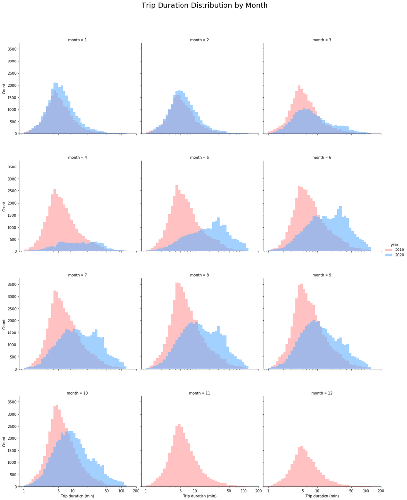

```python
# Trip duration by year, month
ticks = [1, 5, 10, 50, 100, 200]
labels = [1, 5, 10, 50, 100, 200]

g = sns.FacetGrid(data = df, col = 'month', hue = 'year',
                 col_wrap = 3, height = 5, palette=colors_yr)
g.map(plt.hist, 'tripduration', bins = bins, alpha = 0.6).set(xscale = 'log')

# set x, y labels and legend
g.set_xlabels("Trip duration (min)")
g.set_ylabels("Count")
g.add_legend()

# set xticks
for ax in g.axes:
    ax.set_xticks(ticks)
    ax.set_xticklabels(labels)
plt.subplots_adjust(hspace = 0.3)
#g.set(xticks = ticks, xticklabels = labels)


# add main title
plt.subplots_adjust(top = 0.9)
g.fig.suptitle("Trip Duration Distribution by Month", fontsize = 20);
```

## Trip Frequency by Time

First, the plot showed the trip frequency by day of week. Day of week trend shifted from year 2019 to 2020, with higher frequency from weekdays to weekend instead.

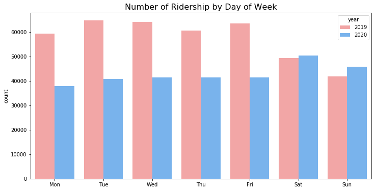

```python
# Countplot: day of week
plt.figure(figsize = [12,6])

day_list = ['Mon','Tue','Wed','Thu','Fri','Sat','Sun']
ax = sns.countplot(data=df, x = 'day_of_week', hue = 'year', palette=colors_yr)

plt.title("Number of Ridership by Day of Week", fontsize = 16)
plt.xticks(ax.get_xticks(), day_list)
plt.xlabel("");
```

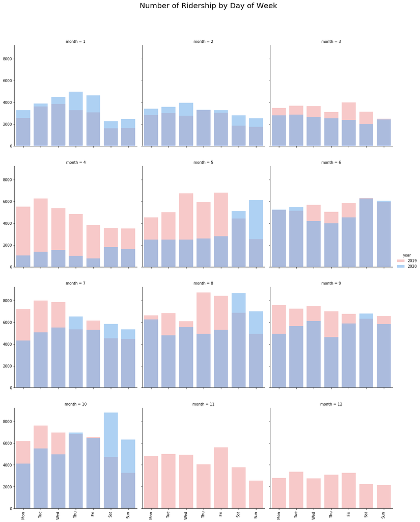

```python
# Facetint by month of the year, countplot for trips frequency by day of week
g = sns.FacetGrid(data = df, col = 'month', hue = 'year',
                 col_wrap = 3, height = 5, palette=colors_yr)
g.map(sns.countplot, 'day_of_week', alpha = 0.6)

g.add_legend()
g.set_xlabels("");

# set xticks
for ax in g.axes.ravel():
    ax.set_xticklabels(day_list, rotation = 90)
plt.subplots_adjust(hspace = 0.2)

# add main title
plt.subplots_adjust(top = 0.9)
g.fig.suptitle("Number of Ridership by Day of Week", fontsize = 20);
```

## Trip Frequency by Time of Day

Two plots by time of day with one hour internal. Time of day trend shifted, from bimodal distribution to left skew started.  
The trend shift in 2020 started around April when the lockdown restiction kicks in (22 March) and most prominent shift in trend observed in May, the month with highest proportion of Customer user.

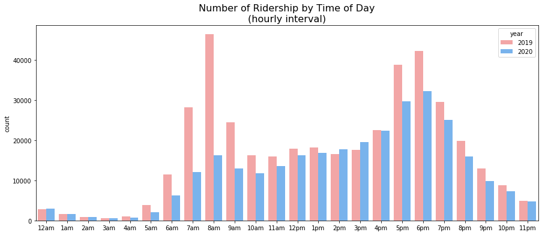

```python
# Countplot: time of day
plt.figure(figsize = [15,6])

ticks_label = ['12am', '1am', '2am', '3am', '4am', '5am', '6am',
'7am', '8am', '9am', '10am', '11am', '12pm', '1pm', '2pm', '3pm', '4pm', '5pm', '6pm',
              '7pm', '8pm', '9pm', '10pm', '11pm']

ax = sns.countplot(data=df, x = 'hour', hue = 'year', palette=colors_yr)
plt.title("Number of Ridership by Time of Day\n(hourly interval)", fontsize = 16)
plt.xticks(ax.get_xticks(), ticks_label)
plt.xlabel("");
```

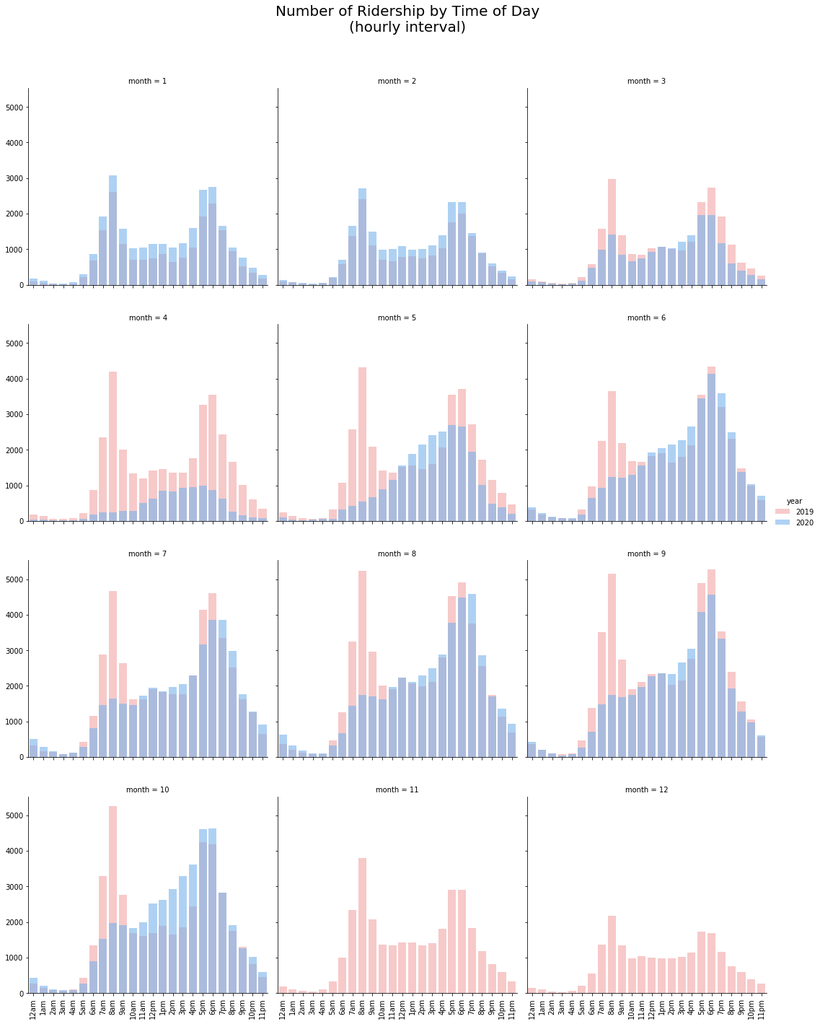

```python
# Faceting by month of the year, countplot for trip frequency by time
g = sns.FacetGrid(data = df, col = 'month', hue = 'year',
                 col_wrap = 3, height = 5, palette=colors_yr)
g.map(sns.countplot, 'hour', alpha = 0.6)

g.add_legend()
g.set_xlabels("");

# set xticks
for ax in g.axes.ravel():
    ax.set_xticklabels(ticks_label, rotation = 90)
plt.subplots_adjust(hspace = 0.2)

# add main title
plt.subplots_adjust(top = 0.9)
g.fig.suptitle("Number of Ridership by Time of Day\n(hourly interval)", fontsize = 20);
```

## Popular Route

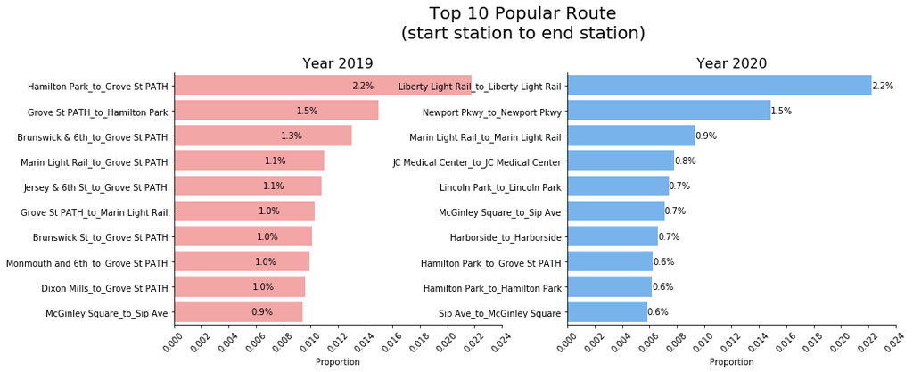

```python
plt.figure(figsize = [15,6])
# main title
plt.subplots_adjust(top = 0.8)
plt.suptitle("Top 10 Popular Route\n(start station to end station)", fontsize = 20)

# Year 2019
plt.subplot(1,2,1)
ax1 = sns.countplot(data = df.query('year == 2019'),
                    y = "route", palette= ['#ff9999'],
                    order = route_order2019);

ax1.spines["top"].set_visible(False)
ax1.spines["right"].set_visible(False)

# label the frequency at the end of each bar
for i in range(num_of_toplist):
    count = route_counts2019[i]
    pct_string = '{:0.1f}%'.format(100*count/df.query('year==2019').shape[0])
    plt.text(count-(count*0.4), i, pct_string, va = "center")

#xticks label
plt.xticks(tick_props*df.query('year==2019').shape[0], tick_names, rotation = 45)
plt.xlabel("Proportion")
plt.ylabel("")
plt.title("Year 2019", fontsize = 16);

# Year 2020
plt.subplot(1,2,2)
ax2 = sns.countplot(data = df.query('year == 2020'),
                    y = "route", palette=['#66b3ff'],
                    order = route_order2020);

ax2.spines["top"].set_visible(False)
ax2.spines["right"].set_visible(False)

# label the frequency at the end of each bar
for i in range(num_of_toplist):
    count = route_counts2020[i]
    pct_string = '{:0.1f}%'.format(100*count/df.query('year==2020').shape[0])
    plt.text(count+1, i, pct_string, va = "center")

#xticks label
plt.xticks(tick_props*df.query('year==2020').shape[0], tick_names, rotation = 45)
plt.xlabel("Proportion")
plt.ylabel("")
plt.title("Year 2020", fontsize = 16);
```

## Popular Route by month

The popular route was ordered starting from top 10 popular route in 2019 and then only followed by the non overlapping top 10 popular route in 2020.  
Looking at the chart facetting by month, the round trip in 2020 is dominant by **Customer** user, particular in the month **May - Aug**.

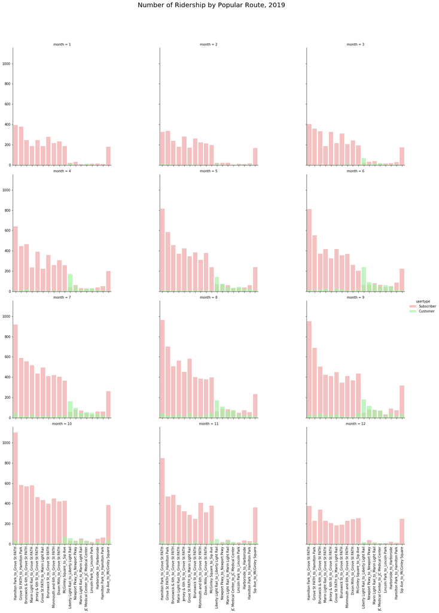

```python
#Year 2019, popular route by time and user type
g = sns.FacetGrid(data = df.query('year == 2019'), col = 'month', hue = 'usertype',
                 col_wrap = 3, height = 6, palette=colors_usertype)
g.map(sns.countplot, 'route',
      order = route_list,
      alpha = 0.7)

g.add_legend()
g.set_xlabels("");

# set xticks
for ax in g.axes.ravel():
    ax.set_xticklabels(route_list,
                       rotation = 90)
#plt.subplots_adjust(hspace = 0.1)

# add main title
plt.subplots_adjust(top = 0.9)
g.fig.suptitle("Number of Ridership by Popular Route, 2019", fontsize = 20);
```

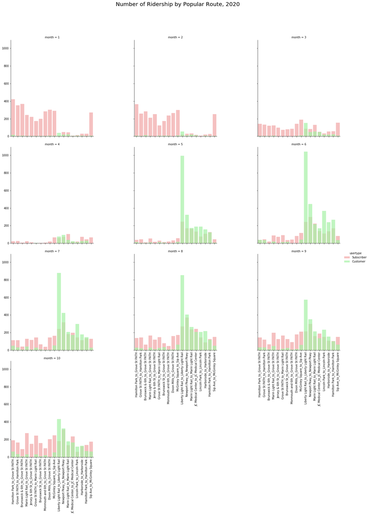

```python
#Year 2020, popular route by time and user type
g = sns.FacetGrid(data = df.query('year == 2020'), col = 'month', hue = 'usertype',
                 col_wrap = 3, height = 6, palette=colors_usertype)
g.map(sns.countplot, 'route',
      order = route_list,
      alpha = 0.7)

g.add_legend()
g.set_xlabels("");

# set xticks
for ax in g.axes.ravel():
    ax.set_xticklabels(route_list,
                       rotation = 90)
#plt.subplots_adjust(hspace = 0.1)

# add main title
plt.subplots_adjust(top = 0.9)
g.fig.suptitle("Number of Ridership by Popular Route, 2020", fontsize = 20);
```